# Problem Set 3

Aaron

2016-09-28

## Objectives

The objectives of this problem set is to gain experience working with data visualization as a tool for understanding unfamiliar data. To do this I want you to submit four *vis* that reveal something interesting about either the included `movies.csv` dataset. For each *vis*, include the code you used to create the plot (`echo=TRUE`), and a one paragraph description of what you found interesting. In most analyses the first plot you try will not be the most informative and you will need to make multiple improvements to get a polished plot. To show this process, for one of your 4 *vis*, provide 3-5 iterations that lead you to the final plot.

Finally, upon completion name your final `.Rmd` file as: `YourName_PS2_ANLY512_SU2016.Rmd` and upload the link to the file from your GitHub repository to the “Problem Set 2”" assignmenet on Moodle.

## My Example

Below is my example for a multi-part question. I have also included an example of loading the data based on requests in last weeks class. I will provide the `movie_data.csv` check Moodle. Add your response in a similar fashion and submit following the directions above.

### Data Import & Cleanup

```r
library(tidyverse)
library(magrittr)
library(stringr)

movie <- read.csv("../data/movie_data.csv")  # import the csv
```

There is a lot to clean up on this data.

```r
# set all column names to lower cases

movie %>%
    transmute(id = id,
              title = as.character(Title),
              release_year = released,
              dom_box = as.numeric(Domestic),
              int_box = as.numeric(International),
              wld_box = as.numeric(Worldwide),
              title_type = Title.type,
              director = Directors,
              avg_rating = AVG.rating,
              imdb_rating = IMDb.Rating,
              imdb_vote = X..of.IMDb.votes,
              rttm_rating = ifelse(Rotten.Tom. == "n/a", NA, as.numeric(as.character(Rotten.Tom.))),
              metc_rating = ifelse(Metacritic == "n/a", NA, as.numeric(as.character(Metacritic))),
              runtime = Runtime..mins.,
              year = Year,
              genres = Genres
              ) %>%
    filter(title_type == "Feature Film") -> movie_f
```

check structure of the data:

```r
str(movie_f)
```

```
## 'data.frame':    2892 obs. of  16 variables:
##  $ id          : int  37 1 95 100 82 99 91 23 39 74 ...
##  $ title       : chr  "Alice in Wonderland" "Avatar" "Batman" "Bruce Almighty" ...
##  $ release_year: int  2010 2009 1989 2003 2014 2006 2010 2003 1994 2013 ...
##  $ dom_box     : num  41 61 5 1 12 2 8 48 39 18 ...
##  $ int_box     : num  55 9 5 1 34 11 18 43 22 33 ...
##  $ wld_box     : num  4 14 17 1 37 19 26 58 35 38 ...
##  $ title_type  : Factor w/ 12 levels "Documentary",..: 2 2 2 2 2 2 2 2 2 2 ...
##  $ director    : Factor w/ 1925 levels "Aaron Blaise, Robert Walker",..: 315 747 1793 1820 120 904 1446 94 1566 55 ...
##  $ avg_rating  : num  74 79 76 66 83 ...
##  $ imdb_rating : num  7.4 7.9 7.6 6.6 8.3 7.2 7.6 8.1 8.7 8.8 ...
##  $ imdb_vote   : int  63718 596840 192085 202760 77440 157310 203915 406471 684507 32711 ...
##  $ rttm_rating : num  NA NA NA NA NA NA NA 99 NA 97 ...
##  $ metc_rating : num  NA NA NA NA NA NA NA 90 NA 96 ...
##  $ runtime     : int  75 162 126 101 136 117 95 100 142 90 ...
##  $ year        : num  1951 2009 1989 2003 2014 ...
##  $ genres      : Factor w/ 773 levels "action","action, adventure",..: 270 45 126 389 56 261 283 253 683 701 ...
```

### Multi-step Visualization

In my example, I want to look at different rating sites and their ratings, each plot would tend to answer one question.

#### Plot 1:

> Does more IMDB votes correlates with higher IMDB ratings?

Self reported movie rating is a very subjective activity, thus I am interested to explore the relationship between # of votes and its rating, since IMDB has most complete rating, I will use this.

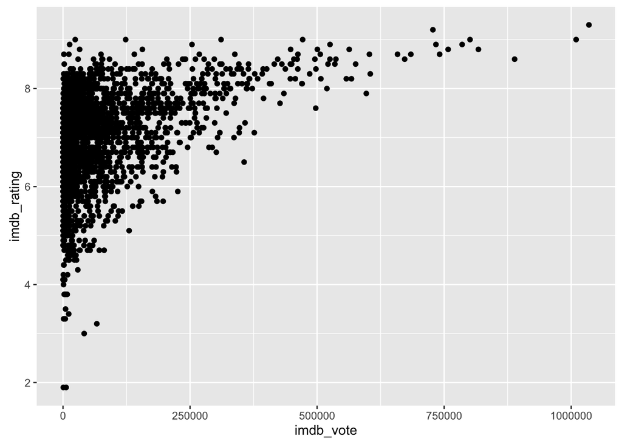

```r
movie_f %>%
    ggplot(aes(imdb_vote, imdb_rating)) +
    geom_point()
```

**Iteration**

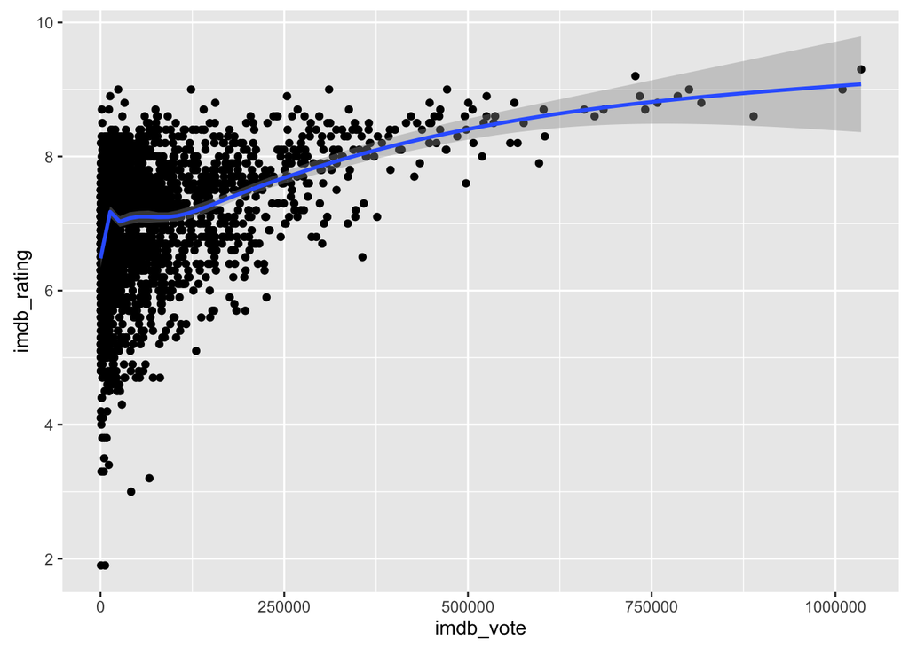

```r
movie_f %>%
    ggplot(aes(imdb_vote, imdb_rating)) +
    geom_point() +
    geom_smooth()
```

This is more clear, there is a slightly positive relationship between number of vote and rating. It could be because people vote tends to come to vote for good movies than bad ones, intuitively.

Now, let’s make it prettier by using Harrisburg U’s color and change alpha.

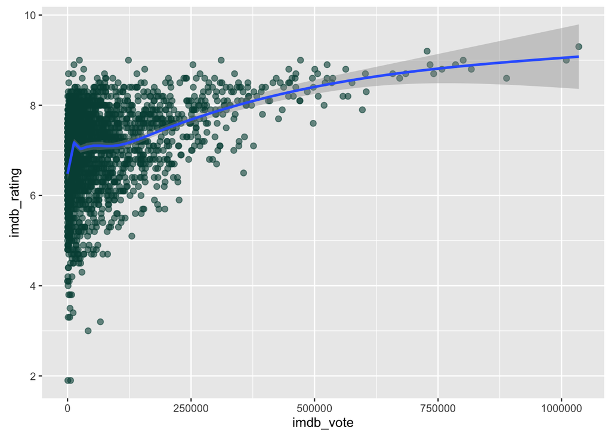

```r
movie_f %>%
    ggplot(aes(imdb_vote, imdb_rating)) +
    geom_point(colour = "#004D43", size = 2, alpha = 0.6) +
    geom_smooth()
```

#### Plot 2: Is drama rated (IMDB) better than comedy?

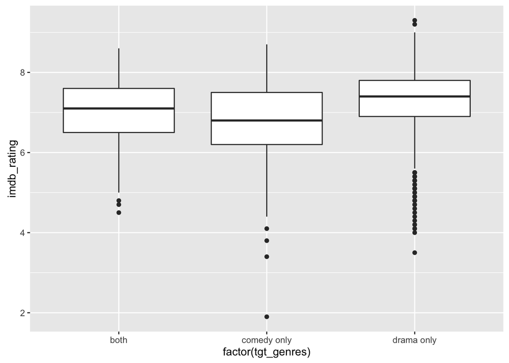

```r
movie_f %>%
    mutate(tgt_genres = ifelse(!str_detect(movie_f$genres, "comedy")&str_detect(movie_f$genres, "drama"), "drama only",
                               ifelse(str_detect(movie_f$genres, "comedy")&!str_detect(movie_f$genres, "drama"), "comedy only",
                               ifelse(str_detect(movie_f$genres, "comedy")&str_detect(movie_f$genres, "drama"), "both", "neither")))
           ) %>%
    filter(tgt_genres %in% c("drama only", "comedy only", "both")) %>%
    ggplot(aes(factor(tgt_genres), imdb_rating)) +
    geom_boxplot()
```

Apprently dramas are rated better than comedy, even the interaction of drama and comedy would give the better a slightly better rating than just comedy.

#### Plot 3:

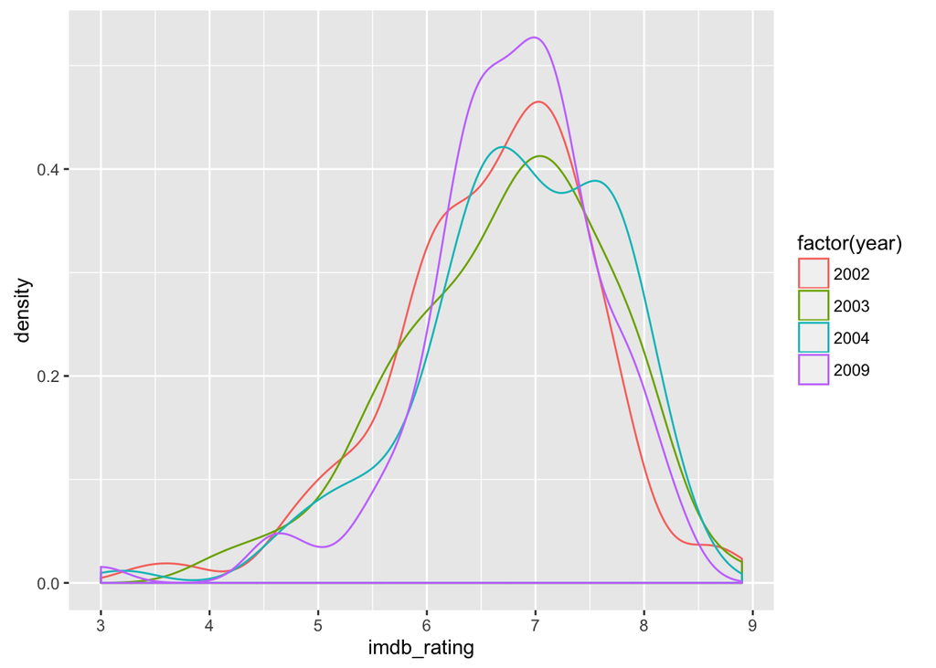

```r
movie_f %>%
    filter(year %in% c(2002, 2009, 2004, 2003)) %>%
    ggplot(aes(x=imdb_rating, colour = factor(year), group = factor(year))) +
    geom_density()
```

Those productive years’ rating are very similar around 7, with year 2009’s rating more condensed.

#### Plot 4:

> how about combine plot 2 and 3 to look at yearly rating distribution by genres?

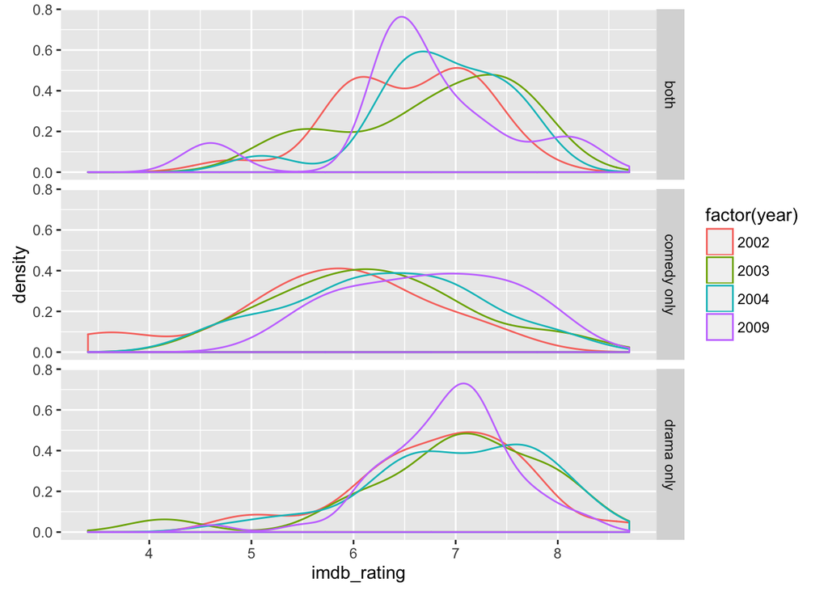

```r
movie_f %>%
    mutate(tgt_genres = ifelse(!str_detect(movie_f$genres, "comedy")&str_detect(movie_f$genres, "drama"), "drama only",
                               ifelse(str_detect(movie_f$genres, "comedy")&!str_detect(movie_f$genres, "drama"), "comedy only",
                               ifelse(str_detect(movie_f$genres, "comedy")&str_detect(movie_f$genres, "drama"), "both", "neither")))
           ) %>%
    filter(tgt_genres %in% c("drama only", "comedy only", "both"),
           year %in% c(2002, 2009, 2004, 2003)) %>%
    ggplot(aes(x=imdb_rating, colour = factor(year), group = factor(year))) +
    geom_density() +
    facet_grid(tgt_genres ~ .)
```